# Презентация по лабораторной работе №5

Аппарат сетей Петри

Люпп Софья Романовна

kulyabov-ds@rudn.ru

Российский университет дружбы народов

2026-04-14

# Информация

## Докладчик

- Люпп Софья Романовна
- студентка НКНбд-01-23
- кафедра теории вероятностей и кибербезопасности
- Российский университет дружбы народов им. П. Лумумбы
- 1132236039@rudn.ru
- https://github.com/srluipp

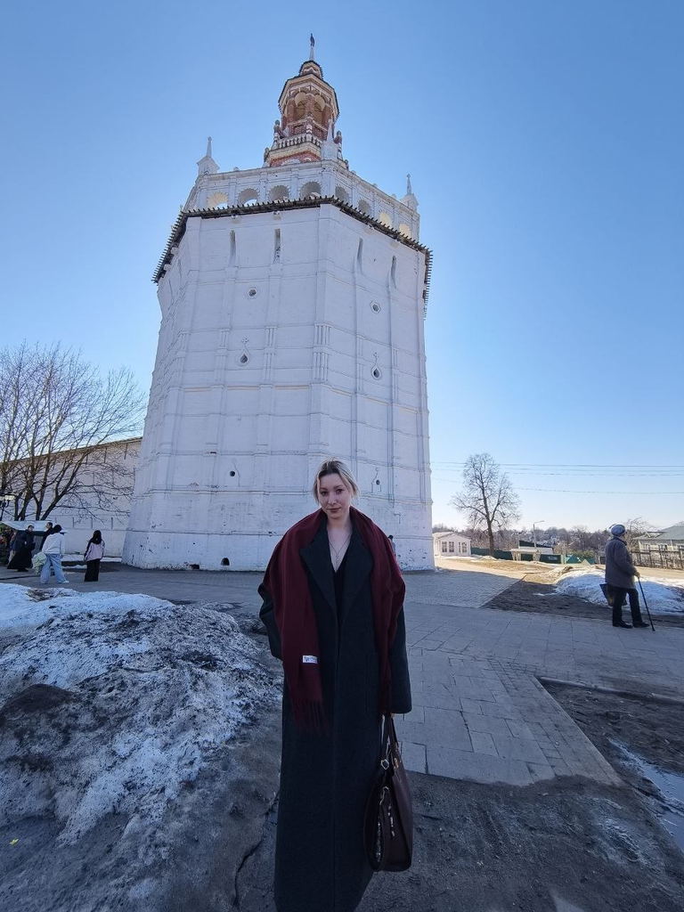

# Вводная часть

## Актуальность

Аппарат сетей Петри применяется в промышленности и производстве, в информационных технологиях, бизнес-процессах, биологиии, медицине. Теория сетей Петри, появившаяся как инструмент для анализа химических процессов, сегодня является мощным и наглядным математическим аппаратом.

## Объект и предмет исследования

Объект исследования: аппарат сетей Петри Предмет исследования: задача обедающих философов

## Цели

Изучить аппарат сетей Петри

## Задачи

1. Изучить теорию по аппарату сетей Петри;
2. Создать необходимые скрипты по заданию;
3. Выполнить отчет и презентацию, преобразовать документацию в формате Quarto и выполнить литературный код.

## Материалы и методы

В качестве материалов к выполнению лабораторной работы была использована работа Имитационное моделирование. Практикум. (А. В. Королькова Кулябов Д. С.)

# DiningPhilosophers

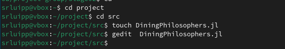

## Dining_philosophers.jl

Создаю скрипт, который выполняет основное моделирование и сравнение двух вариантов сети Петри dining_philosophers.jl, скрипт dining_philosophers_animation.jl, который создает анимацию для наглядной демонстрации динамики работы сети Петри во времени и скрипт dining_philosophers_report.jl, сравнительно анализирующий две модели (с арбитром и без) по ключевому показателю Eat_i (рис. 2).

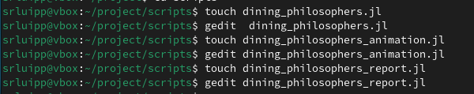

Рисунок 2: Создание скриптов работы

## График classic_simulation

В plots появился график classic_simulation. В классической модели для задачи обедающих философов без арбитра вдет к взаимной блокировке detect_deadlock - true ((рис. 3)

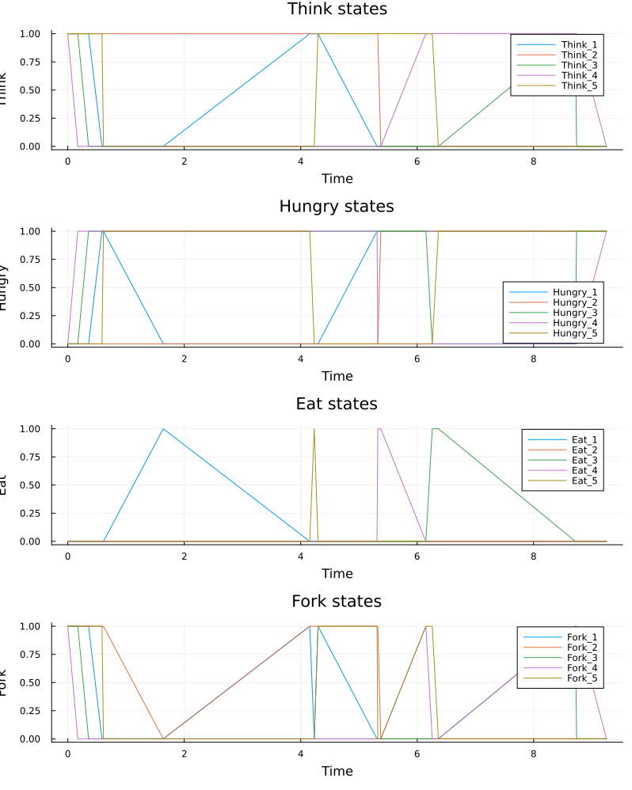

Рисунок 3: classic_simulation

## График arbiter_simulation

В plots появился график arbiter_simulation - это модель с арбитром (дополнительная позиция с N-1 фишками), которая избегает блокировки и возвращает false detect_deadlock (рис. 4)

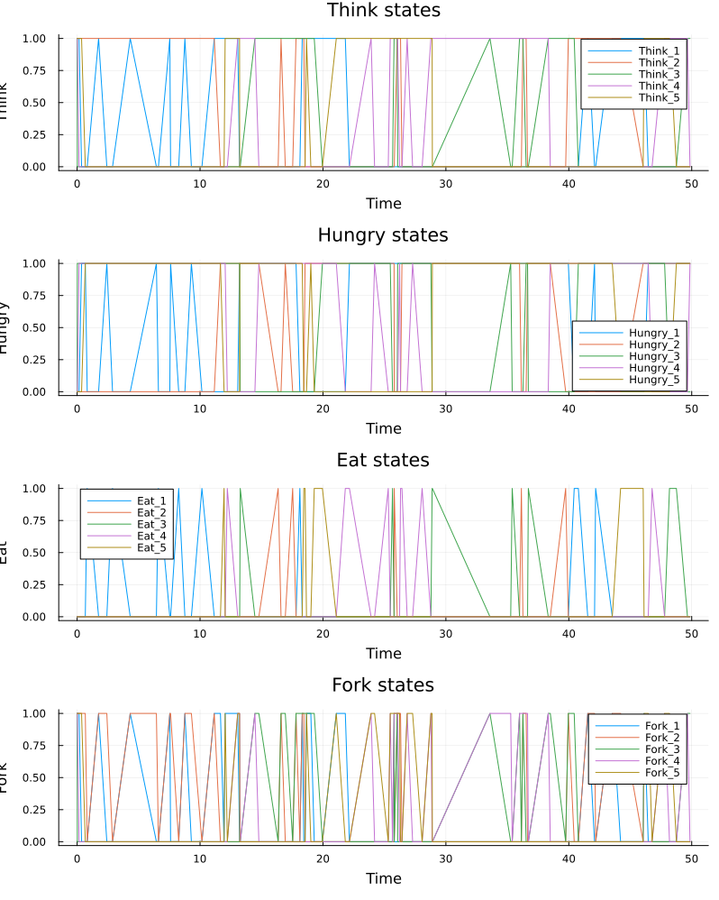

Рисунок 4: arbiter_simulation

## dining_philosophers_animation.jl

Выполняю команду julia для скрипта dining_philosophers_animation.jl (рис. 5). На выходе получается анимация, которая позволяет увидеть, как меняется маркировка в каждой позиции, и особенно наглядно показывает возникновение deadlock в классической модели.

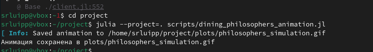

Рисунок 5: dining_philosophers_animation.jl

## final_report

Делаю вывод общего графика сравнительного анализа двух моделей, с арбитром и без (рис. 6).

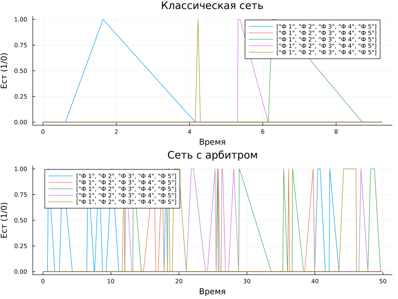

Рисунок 6: final_report

## Результаты

Результатами данной лабораторной работы являются получившиеся графики и анимация в plots

## Итоговый слайд

(рис. 7).

[figure not shown]

Рисунок 7: Обедающие философы